# R Notebook

## Importación y preprocesamiento de los datos

Primero, vamos vamos a leer la base, recodificar algunas variables y generar nuestra variable dicotómica **Y**.

```r
library(tidyverse)

data <- read_delim("./data/enut2021_base.txt", delim = "|")

data <- data %>% select(ID, SEXO_SEL, EDAD_SEL, TCS_GRUPO_DOMESTICO, CONDICION_ACTIVIDAD_AGRUPADA,
                        NIVEL_EDUCATIVO_AGRUPADO, CANT_DEMANDANTES_TOTAL, CANT_NODEMANDANTES_TOTAL,
                        BHCH04_SEL, BHDC_SEL) %>%
  mutate(realiza_domest = as.factor(case_when(
    TCS_GRUPO_DOMESTICO > 60 ~ "Realiza",
    TRUE ~ "No realiza")))

data <- data %>% mutate_at(
                   vars(SEXO_SEL),
                    ~as.factor(case_when(
                      . == 1 ~ "Mujer",
                      . == 2 ~ "Varón"
                    )))


 data <- data %>% mutate_at(vars(CONDICION_ACTIVIDAD_AGRUPADA),
                   ~as.factor(case_when(
                     . == 1 ~ "Ocupado",
                     . == 2 ~ "No ocupado"
                   )))

data <- data %>% mutate_at(vars(BHCH04_SEL),
                   ~as.factor(case_when(
                     . == 1 ~ "Jefe/a",
                     . == 2 ~ "Cónyuge/pareja",
                     . == 3 ~ "Hijo/a",
                     . == 4 ~ "Hijastro/a",
                     . == 5 ~ "Yerno/nuera",
                     . == 6 ~ "Nieto/a",
                     . == 7 ~ "Padre o madre",
                     . == 8 ~ "Suegro/a",
                     . == 9 ~ "Hermano/a",
                     . == 10 ~ "Cuñado/a",
                     . == 11 ~ "Sobrino/a",
                     . == 12 ~ "Abuelo/a",
                     . == 13 ~ "Otro familiar",
                     . == 14 ~ "Otro no familiar")))



 data <- data %>% mutate_at(vars(BHDC_SEL),
                   ~as.factor(case_when(
                     . == 0 ~ "No es demandante de cuidado",
                     . == 1 ~ "Es demandante de cuidado"
                   )))

data <- data %>% select(-TCS_GRUPO_DOMESTICO)
```

# Modelado

## Partición train/test

Lo próximo a hacer para empezar el modelo es crear una partición de datos en train y test. Recuerden que esto es muy importante, ya que queremos entrenar el modelo con nuestro conjunto de datos pero también queremos ver cómo funcionaría con datos nuevos.

```r
set.seed(123)

split <- initial_split(data)
train <- training(split)
test <- testing(split)

table(train$realiza_domest)
```

```
No realiza    Realiza
      3508       7254
```

Creamos modelo con el código simplificado realizando tunning de hiperparámetros.

```r
library(themis)

set.seed(123)

doParallel::registerDoParallel()

# Receta
recipe <- recipe(realiza_domest ~ ., data = train)%>%
  update_role(ID, new_role = "id") %>%
  step_other(BHCH04_SEL, threshold = 0.2)%>%
  step_downsample(realiza_domest, under_ratio = 1)

# Modelo
model <- decision_tree(
  cost_complexity = tune(),
  tree_depth = tune(),
  min_n = tune()
) %>%
  set_engine("rpart") %>%
  set_mode("classification")

# Workflow
wf <- workflow() %>%
  add_recipe(recipe) %>%
  add_model(model)

# Explorar mejores hiperparámetros
tune_grid_result <- wf %>% tune_grid(
    resamples = vfold_cv(train, v = 2),
    grid = grid_regular(cost_complexity(), tree_depth(), min_n(), levels = 4),
    metrics = metric_set(roc_auc, precision,
                         recall, f_meas)
  )

model2 <- finalize_model(model, select_best(tune_grid_result, "roc_auc"))

wf <- wf %>% update_model(model2) %>% fit(train)

wf
```

```
══ Workflow [trained] ══════════════════════════════════════════════════════════════════════════════════════════════════════════
Preprocessor: Recipe
Model: decision_tree()

── Preprocessor ────────────────────────────────────────────────────────────────────────────────────────────────────────────────
2 Recipe Steps

• step_other()
• step_downsample()

── Model ───────────────────────────────────────────────────────────────────────────────────────────────────────────────────────
n= 7016

node), split, n, loss, yval, (yprob)
      * denotes terminal node

    1) root 7016 3508 No realiza (0.50000000 0.50000000)
      2) SEXO_SEL=Varón 3472 1232 No realiza (0.64516129 0.35483871)
        4) EDAD_SEL< 50.5 2363  679 No realiza (0.71265341 0.28734659)
          8) EDAD_SEL< 18.5 276   29 No realiza (0.89492754 0.10507246) *
          9) EDAD_SEL>=18.5 2087  650 No realiza (0.68854816 0.31145184)
           18) CANT_NODEMANDANTES_TOTAL>=1.5 1668  479 No realiza (0.71282974 0.28717026)
             36) CONDICION_ACTIVIDAD_AGRUPADA=Ocupado 1418  381 No realiza (0.73131171 0.26868829)
               72) EDAD_SEL< 29.5 435   91 No realiza (0.79080460 0.20919540) *
               73) EDAD_SEL>=29.5 983  290 No realiza (0.70498474 0.29501526)
                146) CANT_DEMANDANTES_TOTAL>=2.5 86   16 No realiza (0.81395349 0.18604651) *
                147) CANT_DEMANDANTES_TOTAL< 2.5 897  274 No realiza (0.69453735 0.30546265)
                  294) CANT_NODEMANDANTES_TOTAL>=2.5 367   99 No realiza (0.73024523 0.26975477) *
                  295) CANT_NODEMANDANTES_TOTAL< 2.5 530  175 No realiza (0.66981132 0.33018868)
                    590) EDAD_SEL>=48.5 29    4 No realiza (0.86206897 0.13793103) *
                    591) EDAD_SEL< 48.5 501  171 No realiza (0.65868263 0.34131737)
                     1182) EDAD_SEL< 45.5 457  150 No realiza (0.67177243 0.32822757)
                       2364) CANT_DEMANDANTES_TOTAL>=0.5 267   79 No realiza (0.70411985 0.29588015)
                         4728) EDAD_SEL< 41.5 211   55 No realiza (0.73933649 0.26066351) *
                         4729) EDAD_SEL>=41.5 56   24 No realiza (0.57142857 0.42857143)
                           9458) NIVEL_EDUCATIVO_AGRUPADO>=2.5 36   13 No realiza (0.63888889 0.36111111) *
                           9459) NIVEL_EDUCATIVO_AGRUPADO< 2.5 20    9 Realiza (0.45000000 0.55000000) *
                       2365) CANT_DEMANDANTES_TOTAL< 0.5 190   71 No realiza (0.62631579 0.37368421)
                         4730) EDAD_SEL>=42.5 23    4 No realiza (0.82608696 0.17391304) *
                         4731) EDAD_SEL< 42.5 167   67 No realiza (0.59880240 0.40119760)
```

[output cut: 9 more lines]

```
             37) CONDICION_ACTIVIDAD_AGRUPADA=No ocupado 250   98 No realiza (0.60800000 0.39200000)
               74) BHCH04_SEL=other 203   65 No realiza (0.67980296 0.32019704)
                148) CANT_NODEMANDANTES_TOTAL>=3.5 83   20 No realiza (0.75903614 0.24096386) *
                149) CANT_NODEMANDANTES_TOTAL< 3.5 120   45 No realiza (0.62500000 0.37500000)
                  298) EDAD_SEL< 20.5 37    8 No realiza (0.78378378 0.21621622) *
                  299) EDAD_SEL>=20.5 83   37 No realiza (0.55421687 0.44578313)
                    598) EDAD_SEL>=25.5 45   16 No realiza (0.64444444 0.35555556) *
                    599) EDAD_SEL< 25.5 38   17 Realiza (0.44736842 0.55263158) *
               75) BHCH04_SEL=Cónyuge/pareja,Jefe/a 47   14 Realiza (0.29787234 0.70212766) *
           19) CANT_NODEMANDANTES_TOTAL< 1.5 419  171 No realiza (0.59188544 0.40811456)
             38) CONDICION_ACTIVIDAD_AGRUPADA=Ocupado 380  148 No realiza (0.61052632 0.38947368)
               76) EDAD_SEL< 34.5 178   58 No realiza (0.67415730 0.32584270) *

...
and 182 more lines.
```

Creamos modelo con el código simplificado pero sin realizar tunning de hiperparámetros, vamos a elegir valores arbitrariso. **Nota:** siempre es mejor hacer tunning de hiperparámetros!

```r
set.seed(123)

doParallel::registerDoParallel()

# Receta
recipe <- recipe(realiza_domest ~ ., data = train)

# Modelo
model <- decision_tree(
    cost_complexity = 0.01,
    tree_depth = 30,
    min_n = 2
  ) %>%
  set_engine("rpart") %>%
  set_mode("classification")

# Workflow
wf <- workflow() %>%
  add_recipe(recipe) %>%
  add_model(model) %>%
  fit(train)

wf
```

```
══ Workflow [trained] ══════════════════════════════════════════════════════════════════════════════════════════════════════════
Preprocessor: Recipe
Model: decision_tree()

── Preprocessor ────────────────────────────────────────────────────────────────────────────────────────────────────────────────
0 Recipe Steps

── Model ───────────────────────────────────────────────────────────────────────────────────────────────────────────────────────
n= 10762

node), split, n, loss, yval, (yprob)
      * denotes terminal node

1) root 10762 3508 Realiza (0.3259617 0.6740383)
  2) SEXO_SEL=Varón 4772 2240 Realiza (0.4694049 0.5305951)
    4) BHCH04_SEL=Abuelo/a,Cuñado/a,Hijastro/a,Hijo/a,Nieto/a,Otro familiar,Suegro/a,Yerno/nuera 1084  358 No realiza (0.6697417 0.3302583) *
    5) BHCH04_SEL=Cónyuge/pareja,Hermano/a,Jefe/a,Otro no familiar,Padre o madre,Sobrino/a 3688 1514 Realiza (0.4105206 0.5894794) *
  3) SEXO_SEL=Mujer 5990 1268 Realiza (0.2116861 0.7883139) *
```

Explorer la importancia de las variables:

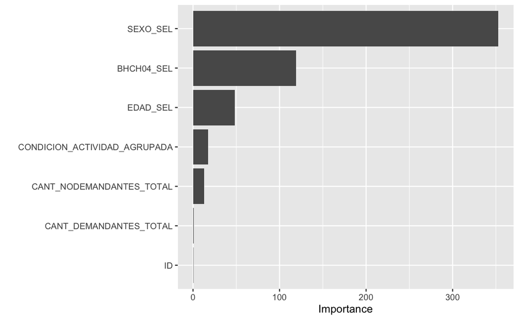

```r
library(vip)
extract_fit_parsnip(wf) %>%
  vip(geom = "col")
```

# Evaluación

Ahora bien, el último paso sería probar esto en el set de validación o test set. Usamos `predict()` para predecir con el modelo los valores de el dataset de testeo, y con `bind_cols()` lo agregamos como una columna.

```r
# Predicciones en test
test2 <- wf %>% predict(test) %>% bind_cols(test, .)
test2
```

| ID | SEXO_SEL | EDAD_SEL | CONDICION_ACTIVIDAD_AGRUPADA | NIVEL_EDUCATIVO_AGRUPADO | CANT_DEMANDANTES_TOTAL | CANT_NODEMANDANTES_TOTAL | BHCH04_SEL | BHDC_SEL | realiza_domest | .pred_class |
| --- | --- | --- | --- | --- | --- | --- | --- | --- | --- | --- |
| 192097 | Mujer | 26 | Ocupado | 4 | 0 | 2 | Jefe/a | No es demandante de cuidado | Realiza | Realiza |
| 185333 | Varón | 43 | Ocupado | 3 | 0 | 1 | Jefe/a | No es demandante de cuidado | No realiza | Realiza |
| 117561 | Mujer | 42 | Ocupado | 4 | 2 | 1 | Jefe/a | No es demandante de cuidado | Realiza | Realiza |
| 111015 | Varón | 52 | Ocupado | 4 | 0 | 1 | Jefe/a | No es demandante de cuidado | No realiza | Realiza |
| 168457 | Mujer | 33 | Ocupado | 4 | 0 | 1 | Jefe/a | No es demandante de cuidado | No realiza | Realiza |
| 161256 | Varón | 36 | Ocupado | 4 | 0 | 1 | Jefe/a | No es demandante de cuidado | No realiza | Realiza |
| 134070 | Mujer | 26 | No ocupado | 3 | 1 | 2 | Hijo/a | No es demandante de cuidado | Realiza | Realiza |
| 173659 | Mujer | 64 | No ocupado | 3 | 0 | 2 | Cónyuge/pareja | No es demandante de cuidado | Realiza | Realiza |
| 125817 | Mujer | 37 | Ocupado | 4 | 0 | 1 | Jefe/a | No es demandante de cuidado | Realiza | Realiza |
| 120528 | Mujer | 60 | Ocupado | 4 | 0 | 2 | Jefe/a | No es demandante de cuidado | Realiza | Realiza |

[output cut: 990 more lines]

¿Cómo vemos las metricas de evaluación? Usamos la funcion `metric_set()`, donde podemos pasar las métricas que queremos ver y lo creamos en un objeto. Luego, a ese objeto le pasamos el dataset, los valores reales y los valores predichos.

```r
class_metrics <- metric_set(precision, accuracy, recall, f_meas)

class_metrics(test2, truth = realiza_domest, estimate = .pred_class)
```

| .metric | .estimator | .estimate |
| --- | --- | --- |
| precision | binary | 0.7033639 |
| accuracy | binary | 0.7087514 |
| recall | binary | 0.1952462 |
| f_meas | binary | 0.3056478 |